# LDA - Linear Discriminant Analysis

J van Melis

2 de setembro de 2018

# Analise de Discriminantes Lineares (ou LDA - Linear Discriminant Analysis)

## IntroduC'C#o geral

A LDA C) uma tC)cnica clC!ssica de anC!lise multivariada, que tem como principais **aplicaC'C5es**:

A **RegressC#o LogC-stica** tambC)m tem o objetivo de usar variC!veis independentes e produzir como resposta o grupo a qual um objeto pertence (1 ou 0, p.ex), mas a LDA:

- Usa regressC#o linear mas C) interpretada de maneira diferente (Grupos ~ X1 + X2b&Xn), pois os b eixos sC#o simplificadosb (FunC'C5es Discriminantes que sC#o construC-das a partir das variC!veis)
- Funciona para separar 2 ou mais grupos.

A LDA e **AnC!lises de Agrupamentos** (Clustering) sC#o semelhantes, pois tem como objetivo a separaC'C#o dos objetos em grupos, mas:

- Ao contrC!rio do clustering, na LDA os grupos jC! sC#o conhecidos (clustering C) C:til para encontrar esses grupos, baseando-se na similaridade entre as observaC'C5es);
- Pode ser usado para classificar novas observaC'C5es que contenham as mesmas variC!veis utilizadas que foram utilizadas para construir as FunC'C5es Discriminates (clustering faz a classificaC'C#o para o que foi observado).

E, finalmente, a LDA C) diferente da **AnC!lise de Componentes Principais** pois, apesar de haver a construC'C#o de uma nova variC!vel que simplifica as variC!veis independentes analisadas, a LDA:

- C mais interessada nos grupos e nC#o em estudar as variC!veis independentes;
- C focada em maximizar a separaC'C#o de grupos conhecidos, enquanto que a PCA foca em reduzir as dimensC5es dos dados;
- O total de variC!veis construC-das serC! sempre o nC:mero de grupos - 1.

Portanto, a LDA tem como principais **objetivos**:

- Observar se existem diferenC'as de grupos em perfil multivariado
- Escolher variC!veis independentes que ajudem a explicar o mC!ximo de diferenC'as no escores dos grupos
- Estabelecer procedimentos para classificar objetos basendo-se em um conjunto de variC!veis independentes

## Pressupostos da LDA

Os principais pressupostos para essa anC!lise C):

- Deve ter os **grupos bem estabelecidos**;
- As variC!veis independentes devem ser **mC)tricas** (quantitativas)
- Essas variC!veis independentes devem seguir **distribuiC'C#o normal** (mas cuidados podem ser feitos)
- As variC!veis devem mostrar-se com **linearidades**;
- **Colinearidades muito altas** devem ser evitadas;
- As **matrizes de variC"ncia-covariC"ncia iguais** entre os grupos;
- O tamanho da **amostra** deve ser considerC!vel (1. mC-nimo 5 observaC'C5es por variC!vel independente; 2. cada grupo deve ter mais objetos que variC!veis independentes analisadas, 3. grupos com tamanhos semelhantes).

## LDA passo-a-passo

Para a execuC'C#o de uma LDA, sabendo claramente de qual C) seu objetivo, o pesquisador deve seguir **6 passos**.

1. Tamanho da Amostra e CriaC'C#o de amostras b treinob e b testeb
2. SeleC'C#o e AnC!lise das variC!veis independentes
3. EstimaC'C#o e AvaliaC'C#o das FunC'C5es Discriminantes
4. InterpretaC'C#o das FunC'C5es Discriminantes
5. ValidaC'C#o Cruzada
6. ConclusC5es

A seguir, executaremos esses 6 passos com o banco de dados de `iris`:

```r
data("iris")
```

e usaremos a funC'C#o `lda` do pacote `MASS`. A saber que ainda existem os pacotes `ade4` e `candisc` que podem executar LDA.

```r
if(!require(MASS)){install.packages('MASS')}
```

### 1. ConsideraC'C#o quanto ao tamanho da Amostra

Primeiramente, verifique quantos objetos tem em cada grupo:

```r
table(iris$Species)
```

```
##
##     setosa versicolor  virginica
##         50         50         50
```

```r
set.seed(51)
n<-length(iris$Species) # quantos objetos existem
sorteio <- sample(1:n, size=n/3)
teste <- iris[-sorteio,]
treino<- iris[sorteio,]
table(teste$Species)
```

```
##
##     setosa versicolor  virginica
##         31         36         33
```

```r
table(treino$Species)
```

```
##
##     setosa versicolor  virginica
##         19         14         17
```

As proporC'C5es ficaram um pouco diferentes, se quiser testar se as proporC'C5es sC#o semelhantes, vocC* pode aplicar um teste de proporC'C5es com $\chi^2$:

Para teste:

```r
n.teste<-as.numeric(table(teste$Species))
teste.prop<-n.teste/100
prop.test(teste.prop, rep(100/3, 3))
```

```
##
##  3-sample test for equality of proportions without continuity
##  correction
##
## data:  teste.prop out of rep(100/3, 3)
## X-squared = 0.0038384, df = 2, p-value = 0.9981
## alternative hypothesis: two.sided
## sample estimates:
## prop 1 prop 2 prop 3
## 0.0093 0.0108 0.0099
```

Para teste:

```r
n.treino<-as.numeric(table(treino$Species))
treino.prop<-n.treino/sum(n.treino)
prop.test(treino.prop, rep(sum(n.treino)/3, 3))
```

```
##
##  3-sample test for equality of proportions without continuity
##  correction
##
## data:  treino.prop out of rep(sum(n.treino)/3, 3)
## X-squared = 0.01551, df = 2, p-value = 0.9923
## alternative hypothesis: two.sided
## sample estimates:
## prop 1 prop 2 prop 3
## 0.0228 0.0168 0.0204
```

Ambas as proporC'C5es seguem a distribuiC'C#o nula (as proporC'C5es sC#o iguais com as proporC'C5es originais, pois para ambos os p-value foram maiores que 0.05)

### 2. SeleC'C#o de variC!veis independentes

Caso vocC* tenha muitas variC!veis (mais do que tem de observaC'C5es em cada grupo), C) interessante reduzir a quantidade de variC!veis a serem utilizadas. O procedimeto a ser utilizado pode ser por avaliaC'C#o das variC!veis por seus pressupostos e correlaC'C5es, mas tambC)m pode ser utilizado o procedimento de *stepwise*.

Para crC-ticas e sugestC5es para efetuar uma LDA com *stepwise* com o R, sugiro a leitura de alguns links, mas resumidamente podemos considerar:

- Quando existem muitas variC!veis preditoras.
- Geralmente o conjunto reduzido C) tC#o bom - ou melhor - que a totalidade das variC!veis.
- C menos estC!vel e generalizC!vel a medida que a proporC'C#o entre amostra e variC!vel independente C) menor que 20.
- Selecionar variC!veis independentes em uma modelagem sem ter nenhuma hipC3tese *a priori* pode levar a falC!cias lC3gicas ou correlaC'C5es espC:rias (alC)m de outros erros).

[1](https://doi:10.1111/j.1399-3054.2010.01431.x) Kozak, M., & Azevedo, R. (2011). Does using stepwise variable selection to build sequential path analysis models make sense? Physiologia plantarum, 141(3), 197-200.

[2](https://doi:10.1111/j.1365-2656.2006.01141.x) Whittingham, M. J., Stephens, P., Bradbury, R. B., & Freckleton, R. P. (2006). Why do we still use stepwise modelling in ecology and behaviour? The Journal of animal ecology, 75(5), 1182-9.

[3](https://www.rdocumentation.org/packages/klaR/versions/0.6-14/topics/stepclass) Pacote `klaR` com a funC'C#o `stepclass()`

No exemplo de `iris`, sC3 temos 4 variC!veis: `Sepal.Length`, `Sepal.Width`, `Petal.Length` e `Petal.Width`, que sC#o o comprimento (*length*) e largura (*width*) das sC)palas (estuturas coloridas mais externas dessa flor, *sepal*) e pC)talas (estruturas mais internas, que sC#o menores que as sC)palas nesse gC*nero de flores, *petal*).

A seguir, exploraremos os pressupostos das variC!veis independentes: (A) Normalidade , (B) Linearidade das relaC'C5es, (C) Multicolinearidade, (D) Igualdade das Matrizes de dispersC#o entre grupos:

#### A. Normalidade das variC!veis independentes

Podemos utilizar de anC!lise visual/grC!fica (QQ-Plot) e/ou estatC-stica (Teste de Shapiro-Wilk) para isso:

Testando a normalidade da variC!vel `Sepal.Length` para cada espC)cie de `iris`:

```r
tapply(treino$Sepal.Length,
         treino$Species,
         shapiro.test)
```

```
## $setosa
##
##  Shapiro-Wilk normality test
##
## data:  X[[i]]
## W = 0.95731, p-value = 0.5206
##
##
## $versicolor
##
##  Shapiro-Wilk normality test
##
## data:  X[[i]]
## W = 0.97837, p-value = 0.9643
##
##
## $virginica
##
##  Shapiro-Wilk normality test
##
## data:  X[[i]]
## W = 0.97171, p-value = 0.8477
```

Testando a normalidade da variC!vel `Sepal.Width` para cada espC)cie de `iris`

```r
tapply(treino$Sepal.Width,
         treino$Species,
         shapiro.test)
```

```
## $setosa
##
##  Shapiro-Wilk normality test
##
## data:  X[[i]]
## W = 0.94973, p-value = 0.391
##
##
## $versicolor
##
##  Shapiro-Wilk normality test
##
## data:  X[[i]]
## W = 0.93949, p-value = 0.4119
##
##
## $virginica
##
##  Shapiro-Wilk normality test
##
## data:  X[[i]]
## W = 0.89713, p-value = 0.06082
```

Testando a normalidade da variC!vel `Petal.Length` para cada espC)cie de `iris`

```r
tapply(treino$Petal.Length,
         treino$Species,
         shapiro.test)
```

```
## $setosa
##
##  Shapiro-Wilk normality test
##
## data:  X[[i]]
## W = 0.9501, p-value = 0.3967
##
##
## $versicolor
##
##  Shapiro-Wilk normality test
##
## data:  X[[i]]
## W = 0.94538, p-value = 0.4915
##
##
## $virginica
##
##  Shapiro-Wilk normality test
##
## data:  X[[i]]
## W = 0.9516, p-value = 0.4823
```

Testando a normalidade da variC!vel `Petal.Width` para cada espC)cie de `iris`

```r
tapply(treino$Petal.Width,
         treino$Species,
         shapiro.test)
```

```
## $setosa
##
##  Shapiro-Wilk normality test
##
## data:  X[[i]]
## W = 0.80717, p-value = 0.001456
##
##
## $versicolor
##
##  Shapiro-Wilk normality test
##
## data:  X[[i]]
## W = 0.92061, p-value = 0.2244
##
##
## $virginica
##
##  Shapiro-Wilk normality test
##
## data:  X[[i]]
## W = 0.94992, p-value = 0.4553
```

QQ-plot de todas as variC!veis, nas linhas sC#o as espC)cies (1 a 3) e nas colunas as variC!veis (de 1 a 4):

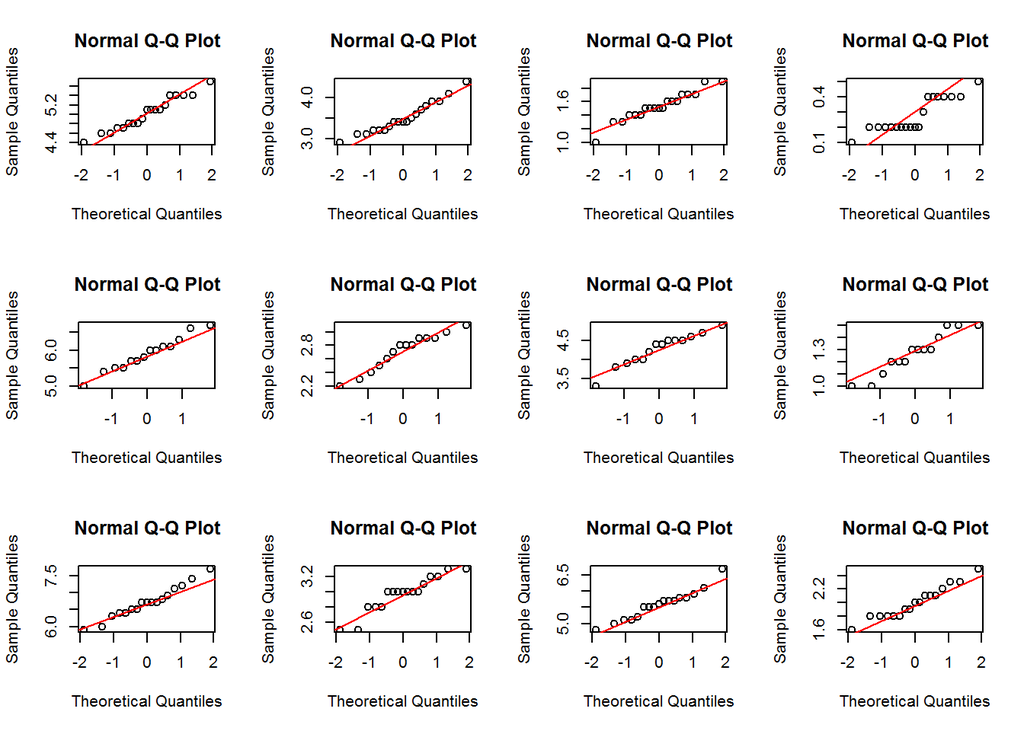

```r
par(mfrow=c(3,4))
species<-levels(treino$Species)
for (i in 1:3){
  for (j in 1:4){
    qqnorm(treino[,j][treino$Species==species[i]])
    qqline(treino[,j][treino$Species==species[i]], col="red")
  }
}
```

TerC-amos problemas maiores se todas ou maior parte das variC!veis para 1 espC)cie nC#o mostrasse distribuiC'C#o normal ou se uma ou mais variC!veis nC#o mostrarem distribuiC'C#o normal para todas as espC)cies. NC#o C) o nosso caso

#### B. Linearidade de relaC'C5es

FaC'a uma verificaC'C#o visual das relaC'C5es entre as variC!veis, para ver se alguma das relaC'C5es mostra-se com alguma relaC'C#o nao linear (p.ex: quadrC!tica, exponencial, etc). Pessoalmente, gosto de fazer essa anC!lise visual com o pacote `GGally` , muito similar ao `ggplot2`:

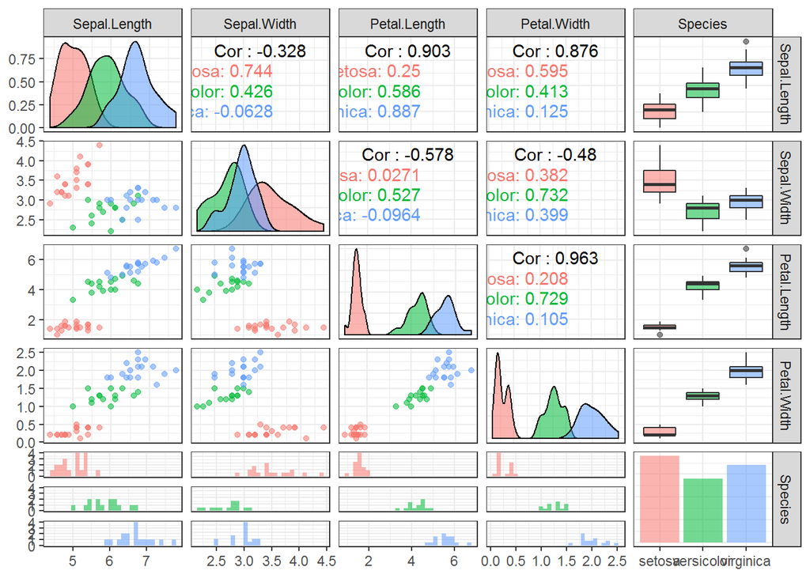

```r
GGally::ggpairs(treino, aes(colour = Species, alpha = 0.4))+theme_bw()
```

#### C. Falta de multicolinearidade entre variC!veis independentes

Para isso, C) importante verificar a correlaC'C#o entre as variC!veis. Pelo grC!fico anterior jC! pudemos perceber que `Petal.Width` e `Petal.Length` sC#o altamente correlacionadas:

```r
cor(treino[,1:4])
```

```
##              Sepal.Length Sepal.Width Petal.Length Petal.Width
## Sepal.Length    1.0000000  -0.3279009    0.9026614   0.8758369
## Sepal.Width    -0.3279009   1.0000000   -0.5776848  -0.4800897
## Petal.Length    0.9026614  -0.5776848    1.0000000   0.9625962
## Petal.Width     0.8758369  -0.4800897    0.9625962   1.0000000
```

A qual podemos verificar pela correlaC'C#o alta = 0.9625962.

Se tivC)ssemos muitas variC!veis, essas duas variC!veis poderiam ser sintetizadas em uma C:nica, portanto vocC* poderia utilizar somente `Petal.Width` ou `Petal.Length`, por exemplo. NC3s manteremos o uso das duas variC!veis, pois o nosso modelo LDA pode perder poder de discriminaC'C#o se usarmos poucas variC!vels.

#### D. Matrizes de dispersC#o iguais

As Matrizes de variC"ncias-covariC"ncias devem ser iguais entre os grupos. Para isso, podemos executar o teste M de Box. Para executarmos uma LDA, amostras pequenas e matrizes de covariC"ncia desiguais afetam negativamente a significC"ncia do processo de estimaC'C#o das funC'C5es discriminantes.

O pacote `biotools` possui a funC'C#o `boxM()` para que possamos executar esse teste:

```r
biotools::boxM(treino[,1:4],treino$Species)
```

```
##
##  Box's M-test for Homogeneity of Covariance Matrices
##
## data:  treino[, 1:4]
## Chi-Sq (approx.) = 48.374, df = 20, p-value = 0.0003769
```

Infelizmente o teste M de Box (Boxbs M test) C) muito sensC-vel C violaC'C5es da normalidade, levando a rejeiC'C#o de grande parte dos casos, que C) o nosso caso (p-value <0.01, logo rejeitamos a hipC3tese nula de que as matrizes sC#o iguais entre os grupos).

Quando as matrizes sC#o diferentes, a sugestC#o C) (i) utilizar QDA ao invC)s de LDA ou (ii) fazermos uma validaC'C#o cruzada dos dados, com a separaC'C#o das amostras emm `treino` e em `teste`, como fizemos, e testar se o modelo construC-do tem um bom ajuste (verificar tabela confusC#o)

### 3. EstimaC'C#o e AvaliaC'C#o das FunC'C5es Discriminantes

No R existem muitos pacotes e maneira de realizar uma lda. Pessoalmente, prefiro a funC'C#o `lda()` do pacote `MASS`, pois tem um *output* limpo e a forma de escrever a funC'C#o C) muito parecida com um modelo linear (`lm()` ou `glm()`):

```r
dis1 <- MASS::lda(Species~., data = treino)
dis2 <- MASS::lda(Species~., data = treino, CV=TRUE) # cross-validation
```

com o argumento `CV=TRUE`, a funC'C#o `lda()` executa um *cros-validation*. A principal diferenC'a de *output* C) que com `CV=TRUE` hC! uma tabela no resultado da LDA chamado `posterior` (`dis2$posterior`), que sC#o as **probabilidades** de serem classificadas em cada uma das espC)cies (*Iris setosa*, *I. versicolor* e *I. virginica*) pela FD (funC'C#o de ClassificaC'C#o, tambC)m chamada de FunC'C#o Discriminante Linear de Fisher) construC-da.

Esse objeto `posterior` C) muito semelhante (se a sua FD estiver boa) com o resultado da aplicaC'C#o da FD nos dados inseridos (`predict(dis1)`), que tambC)m possui uma tabela `posterior`, com as probabilidades de cada observaC'C#o pertencer a um determinado grupo (`setosa`, `versicolor` ou `virginica`):

```r
previsto <- predict(dis1)
head(round(previsto$posterior,4))
```

```
##     setosa versicolor virginica
## 117      0      5e-04    0.9995
## 30       1      0e+00    0.0000
## 45       1      0e+00    0.0000
## 145      0      0e+00    1.0000
## 32       1      0e+00    0.0000
## 121      0      0e+00    1.0000
```

Essas probabilidades sC#o obtidas pelos valores das funC'C5es discriminantes (escores) obtidas para cada objeto (observaC'C#o). Esses valores podem ser obtidos na tabela `x` do objeto `previsto` (resultante do `predict(dis1)`)

```r
escores <- predict(dis1)$x
head(escores)
```

```
##           LD1        LD2
## 117 -6.020032 -0.1208288
## 30   7.270713  0.8553593
## 45   6.940789 -0.9090834
## 145 -8.548507 -2.3812622
## 32   7.482865 -0.5724178
## 121 -7.784787 -1.8098406
```

Lembrando que sC#o construC-dos um nC:mero de $N-1$ funC'C5es discriminantes, sendo $N$ o nC:mero de grupos existentes. No nosso caso, foram construC-dos 2 pois temos 3 grupos (espC)cies): LD1 e LD2.

Os escores dessas funC'C5es discriminantes (`LD1` e `LD2`) sC#o importantes para fazer as separaC'C5es dos grupos. O escore discriminante C) `0` para cada um dos LD, portanto, cada grupo C) separado pelo seu sinal. A primeira LD (`LD1`) separa 1 grupo do restante dos grupos. Um objeto serC! classificado de 1 grupo determinado se apresentar valor positivo ou pertencerC! ao restante se apresentar valor negativo. As LDs sC#o sendo construC-das atC) conseguirmos separar todos os grupos do restante. Por isso que o nC:mero de LDs serC! $N-1$.

O prC3ximo passo C) fazer a avaliC'C#o da precisC#o preditiva, para isso C) construC-do uma matriz confusC#o, contrastando o que C) previsto pelo modelo e a qual grupo que pertence realmente aquela observaC'C#o:

```r
grupos_previstos <- predict(dis1)$class
grupos_reais <-  treino$Species
tabela<-table(grupos_previstos, grupos_reais)
tabela
```

```
##                 grupos_reais
## grupos_previstos setosa versicolor virginica
##       setosa         19          0         0
##       versicolor      0         14         0
##       virginica       0          0        17
```

Para observamos as porcentagens de acertos, verificamos a mC)dia da diagonal da matriz confusC#o:

```r
mean(
  diag(tabela)/
  table(grupos_reais)
  )
```

```
## [1] 1
```

### 4. InterpretaC'C#o das FunC'C5es Discriminantes

Para isso serC! necessC!rio ver os escores das **cargas discriminantes** (correlaC'C5es das variC!veis independentes com as LD -funC'C5es discriminantes - construC-das). os valores estC#o contidos no objeto resultante da `lda()` na tabela `scaling`:

```r
dis1$scaling
```

```
##                     LD1        LD2
## Sepal.Length  0.7043947 -0.6091423
## Sepal.Width   1.2961323 -2.1898977
## Petal.Length -2.1230252  0.8913771
## Petal.Width  -3.7622694 -2.3713015
```

Portanto, quanto **maior** o escore de LD1 para um objeto (observaC'C#o), **maior** C) o comprimento da SC)pala, porC)m **menor** para a largura da PC)tala, pois as correlaC'C5es sC#o positiva e negativa respectivamente de `LD1` com `Sepal.Length` e `Petal.Width`.

Para melhor interpretarmos como foi feita a classificaC'C#o segundo essas funC'C5es discriminates, podemos ver os Centroides dos grupos

```r
escores<-predict(dis1, treino)$x
resulta<-data.frame(predict(dis1, treino)$x,
                    species = predict(dis1,treino)$class)
centroides<-data.frame(
  LD1=tapply(resulta$LD1, resulta$species, mean),
  LD2=tapply(resulta$LD2, resulta$species, mean))
centroides
```

```
##                  LD1        LD2
## setosa      7.737698 -0.2436531
## versicolor -2.220232  1.0466005
## virginica  -6.819589 -0.5895881
```

Ou seja, a primeira LD discriminou `setosa` do restante (valores positivos pertencem a `setosa` e valores negativos pertecem C s outras duas espC)cies) e a segunda LD discriminou entre `versicolor` (valores positivos) e `virginica` (valores negativos).

Podemos observar com o grC!fico dos escores e seus centrC3ides (+) para cada espC)cie:

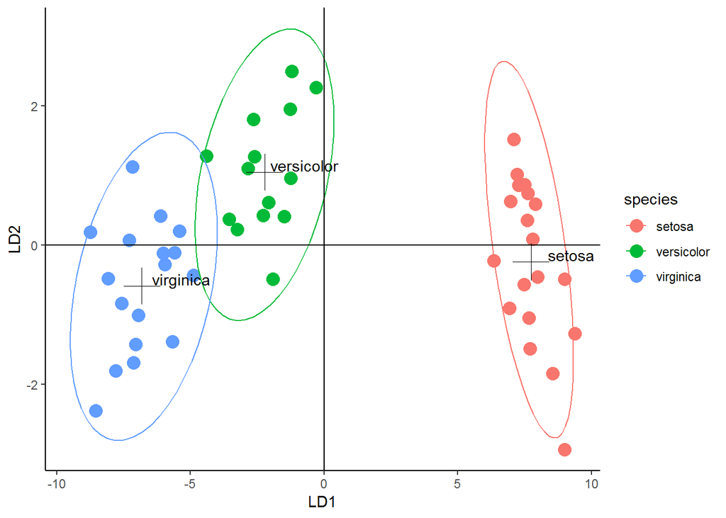

```r
ggplot(resulta, aes(x=LD1, y=LD2, color=species))+
  geom_point(size=4)+
  stat_ellipse()+
  geom_text(data=centroides, aes(x=LD1+1.5, y=LD2+0.1, label=species), color="black")+
  geom_point(data=centroides, aes(x=LD1, y=LD2), color="black",size=8, shape=3)+
  theme_classic()+
  geom_hline(yintercept = 0)+
  geom_vline(xintercept = 0)
```

Para verificar se as LDs apresentam significC"ncia, podemos utilizar o valor de Lambda de Wilk: Testa a significancia estatistica do poder discriminatC3rio da(s) funC'C#o(C5es) discriminante(s). Wilksb lambda: varia de 1.0 (sem poder discriminatorio) ate 0.0 (poder discriminatorio perfeito). A hipC3tese nula neste caso C) que *nC#o hC! diferenC'a significativa entre os centroides dos grupos*

```r
escores<-predict(
  lda(Species~.,data=treino)
                 )$x # valores de FD para observacao
real <- treino$Species
summary.aov(manova(escores ~ real),test="Wilks")
```

```
##  Response LD1 :
##             Df Sum Sq Mean Sq F value    Pr(>F)
## real         2 1997.2   998.6   998.6 < 2.2e-16 ***
## Residuals   47   47.0     1.0
## ---
## Signif. codes:  0 '***' 0.001 '**' 0.01 '*' 0.05 '.' 0.1 ' ' 1
##
##  Response LD2 :
##             Df Sum Sq Mean Sq F value    Pr(>F)
## real         2 22.373  11.186  11.186 0.0001063 ***
## Residuals   47 47.000   1.000
## ---
## Signif. codes:  0 '***' 0.001 '**' 0.01 '*' 0.05 '.' 0.1 ' ' 1
```

Para ambas funcC5es (LD1 e LD2) foi significativo, ou seja, os centroides dos grupos sC#o diferentes entre si.

### 5. ValidaC'C#o Cruzada

Podemos verificar se a nossa amostra `teste` tambC)m responderC! com um bom desempenho para a FD construC-da com os dados de `treino` (verificando o *overfitting*):

```r
grupos_previstos <- predict(dis1, teste)$class
grupos_reais <-  teste$Species
tabela <- table(grupos_previstos, grupos_reais)
tabela
```

```
##                 grupos_reais
## grupos_previstos setosa versicolor virginica
##       setosa         31          0         0
##       versicolor      0         33         1
##       virginica       0          3        32
```

Para observamos as porcentagens de acertos, verificamos a mC)dia da diagonal da matriz confusC#o:

```r
mean(
  diag(tabela)/
  table(grupos_reais)
  )
```

```
## [1] 0.9621212
```

### 6. ConclusC5es

Qual grupo mostra discriminaC'C#o clara e significante para a primeira **funC'C#o discriminante**?

Quais variC!veis independentes mostraram coeficientes (**Cargas Fatoriais** ou **Peso Discriminante**) positivos ou negativos com essa primeira funC'C#o discrimiante?

Qual C) a sua conclusC#o, baseando-se nas duas respostas anteriores? Ou seja, qual espC)cie apresenta pC)talas/sC)palas menores/maiores e estreitas/largas?